# SI618_Project_Report

Jun Wang wanjun 51383890

Dec. 16 2016

## 1. Motivation

- 1. In this project, we want to perform the exploratory analysis about the weather in New York City, given that I am going to work at Big Apple. We want to explore the norm and the exception of the weather in New York City, especially the weather of New York in the winter, so that we can get familiar with the climate in advance.
- 2. The four specific questions we want to explore are:
  - 1.How does the weather look like in New York’s winter?
  - 2.When the hurricane stuck, how did the weather like in New York, especially the life-threaten hurricane?
  - 3.The annual weather analysis New York City.
  - 4.The difference between the weather of the urban area and the rural area in New York.

## 2. Data Source

- The datasets are pulled from the API provided by NOAA (National Centers for Environmental Information). The weather data from weather stations is available at the specific location of the weather station across all the country, and it is often useful to have estimates of daily or hourly weather aggregated on a larger spatial level, so that it can be particularly useful to be able to pull time series of weather by county. The base URL of API is [http://www.ncdc.noaa.gov/cdo-web/api/v2/{endpoint}](http://www.ncdc.noaa.gov/cdo-web/api/v2/%7Bendpoint%7D), and the endpoint can be the specific category of the weather data we request, such as datasets, locations and stations. Here, the R packages, *rnoaa* and *countyweather* provide useful and integrated weather data access methods, so here we use the functions in package *countyweather* to retrieve the data directly. The functions in the package *countyweather* compiles the weather data accessed from the package *rnoaa* in advance for us, so that we can retrieve the weather data in specific weather station in specific period through simply and direct methods. To use these two packages, we need to request an API key from NOAA here: http://www.ncdc.noaa.gov/cdo-web/token. Once you have this NOAA API key, you’ll need to pass it through to some of the functions in this package that pull data from NOAA. The most secure way to use this API key is to store it in your *.Renviron* configuration file, and then you can set it up as the value of an object in R code or R markdown documents without having to include the key itself in the script. Once you have opened or created an .Renviron file, type the following into the file, **noaakey=your_key**. Before using functions that require the API key, set up the object *rnoaakey* to have your NOAA API key by running: **options(“noaakey” = Sys.getenv(“noaakey”))**. Notice that it will take a while to retrieve data from the API.
- The main variables the datasets include are *time* in date format, *positions* in character format, *precipitation, wind speed, snow fall, snow depth, maximum temperature, minimum temperature* in numeric format and etc.
- The number of records depends on the length of the time we want to analysis. For example, if we want to perform the annual analysis on the weather of a location, we shuold retrieve 365 records of the weather data.
- In the annual anlysis, we cover a whole year. When we analysis the winter, we cover 4 winter months. The weeks in which the hurricane stuck are selected.

## 3. Methods

We just need to specify the weather variables and the weather station and the periods we want to analysis when we retrieve the weather data. The function *daily_fips* and *hourly_fips* is mainly used to retrieve the weather data. For *hourly_fips* and *daily_fips*, and time series functions, we can choose to filter out any weather stations that report variables for less that a certain percent of time (coverage), then we can handle the missing and the incomplete data in the data retrieve step. The function will average the weather data collected from all the weather stations in one county in default, so that the noisy is eliminated by the averaged data, and the averaged data can also handle the missing data and incomplete data ex-ante.

## 4. Analysis and Results

- 1.How does the weather look like in New York’s winter? The weather station map is shown as the geographical plot, and the head of the weather data of the winter in 2015 is also presented.

```
## [1] "LC_COLLATE=English_United States.1252;LC_CTYPE=English_United States.1252;LC_MONETARY=English_United States.1252;LC_NUMERIC=C;LC_TIME=English_United States.1252"
```

```
## Getting daily weather data for New York County, New York. This may take a while.
```

```
## Getting daily weather data for New York County, New York. This may take a while.
## Getting daily weather data for New York County, New York. This may take a while.
```

```
## $daily_data
NA
##          date  prcp  snow  snwd  tmax  tmin prcp_reporting snow_reporting
##        <date> <dbl> <dbl> <dbl> <dbl> <dbl>          <int>          <int>
## 1  2015-12-01   8.4     0     0  10.6   6.7              1              1
## 2  2015-12-02   3.6     0     0  13.9   7.8              1              1
## 3  2015-12-03   0.0     0     0  12.8   6.7              1              1
## 4  2015-12-04   0.0     0     0  10.6   5.6              1              1
## 5  2015-12-05   0.0     0     0  10.6   4.4              1              1
## 6  2015-12-06   0.0     0     0  11.7   3.9              1              1
## 7  2015-12-07   0.0     0     0  12.2   5.6              1              1
## 8  2015-12-08   0.0     0     0   9.4   5.0              1              1
## 9  2015-12-09   0.0     0     0  12.8   4.4              1              1
## 10 2015-12-10   0.0     0     0  15.6  10.6              1              1
## # ... with 112 more rows, and 3 more variables: snwd_reporting <int>,
## #   tmax_reporting <int>, tmin_reporting <int>
##
## $station_metadata
## Source: local data frame [5 x 10]
## Groups: id [1]
##
##            id                        name   var latitude longitude
##         <chr>                       <chr> <chr>    <dbl>     <dbl>
## 1 USW00094728 NY CITY CENTRAL PARK, NY US  prcp  40.7889  -73.9669
## 2 USW00094728 NY CITY CENTRAL PARK, NY US  snow  40.7889  -73.9669
## 3 USW00094728 NY CITY CENTRAL PARK, NY US  snwd  40.7889  -73.9669
## 4 USW00094728 NY CITY CENTRAL PARK, NY US  tmax  40.7889  -73.9669
## 5 USW00094728 NY CITY CENTRAL PARK, NY US  tmin  40.7889  -73.9669
## # ... with 5 more variables: calc_coverage <dbl>, standard_dev <dbl>,
## #   min <dbl>, max <dbl>, range <dbl>
##
## $station_map
```

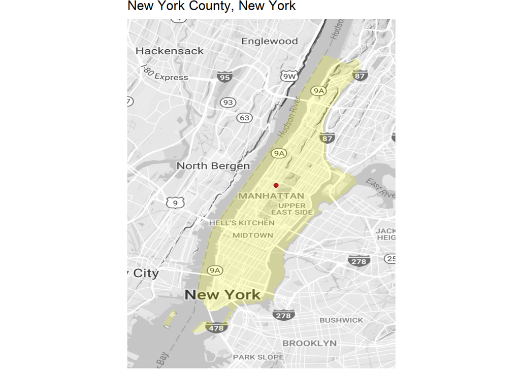

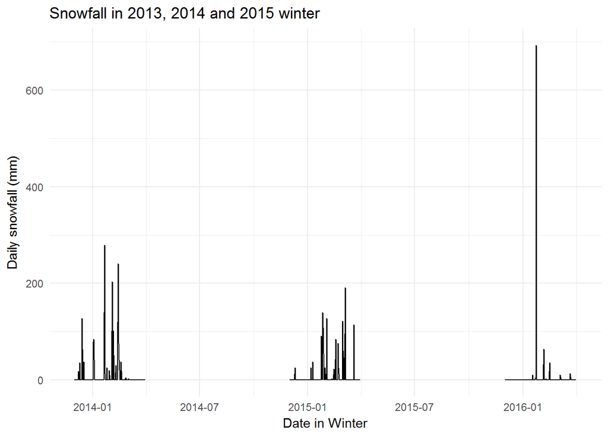

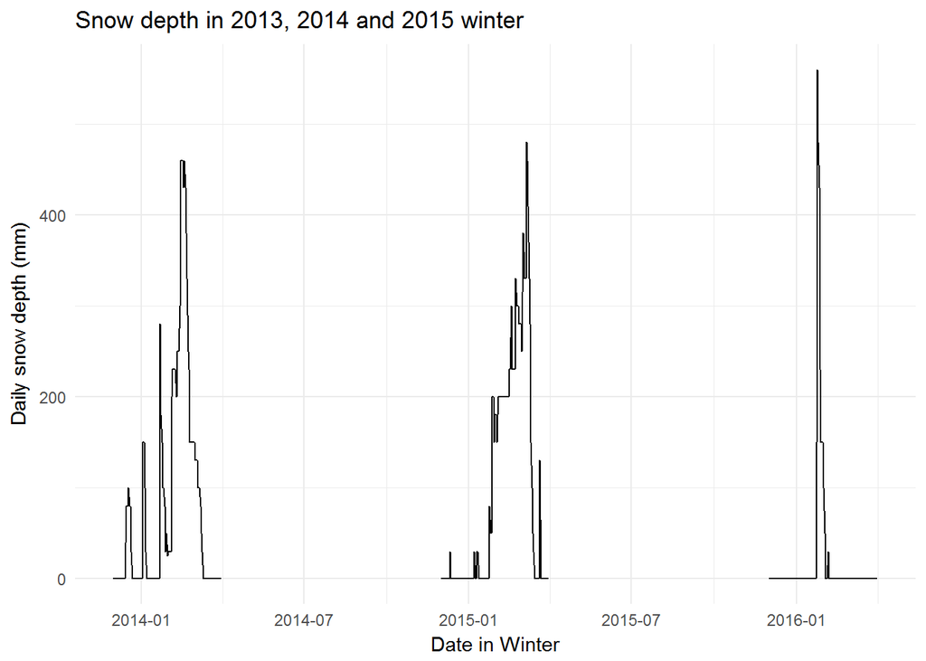

```
##   Years mean temperature in winter
## 1  2013                  1.2475207
## 2  2014                  0.7764463
## 3  2015                  6.1532787
```

```
##   Years mean precipitation in winter
## 1  2013                     3.526446
## 2  2014                     3.785950
## 3  2015                     3.064754
```

The mean temperature in 2015 winter is apparently higher than it in 2014 winter and 2013 winter, which also proves an evidence of less snow in 2015 winter. While the averaged precipitation in these three years is similar.

- 2.When the hurricane stuck, how did the weather like in New York, especially the life-threaten hurricane? The storm surge of Hurricane Sandy hit New York on Oct. 29, 2012, flooding streets, tunnels and subway lines and cutting power in and around the city, causing 53 fatalities. Hurricane Irene hit New York City on Aug. 28, 2011, and it caused 5 fatalities. The weather station map is shown as the geographical plot, and the head of the weather data collected by the station when Hurricane Sandy hit is also presented.

```
## Getting daily weather data for New York County, New York. This may take a while.
## Getting daily weather data for New York County, New York. This may take a while.
```

```
## Getting hourly weather data for New York County, New York. This may take a while.
## Getting hourly weather data for New York County, New York. This may take a while.
```

```
## $hourly_data
NA
##              date_time temperature wind_speed temperature_reporting
##                 <dttm>       <dbl>      <dbl>                 <int>
## 1  2012-01-01 00:51:00        10.0        2.6                     1
## 2  2012-01-01 01:51:00         9.4        4.6                     1
## 3  2012-01-01 02:51:00         8.3        3.1                     1
## 4  2012-01-01 03:00:00         5.6        6.7                     1
## 5  2012-01-01 03:51:00         8.3        2.6                     1
## 6  2012-01-01 04:51:00         7.8        3.6                     1
## 7  2012-01-01 04:59:00         NaN        NaN                     0
## 8  2012-01-01 05:51:00         7.8        2.6                     1
## 9  2012-01-01 06:51:00         7.2        3.1                     1
## 10 2012-01-01 07:51:00         7.2        2.6                     1
## # ... with 12,207 more rows, and 1 more variables:
## #   wind_speed_reporting <int>
##
## $station_metadata
NA
##     usaf  wban      station          station_name         var
##    <chr> <chr>        <chr>                 <chr>       <chr>
## 1 725060 94728 725060-94728 NEW YORK CENTRAL PARK  wind_speed
## 2 725053 94728 725053-94728          CENTRAL PARK  wind_speed
## 3 725060 94728 725060-94728 NEW YORK CENTRAL PARK temperature
## 4 725053 94728 725053-94728          CENTRAL PARK temperature
## # ... with 10 more variables: calc_coverage <dbl>, standard_dev <dbl>,
## #   range <dbl>, ctry <chr>, state <chr>, elev_m <dbl>, begin <dbl>,
## #   end <dbl>, longitude <dbl>, latitude <dbl>
##
## $station_map
```

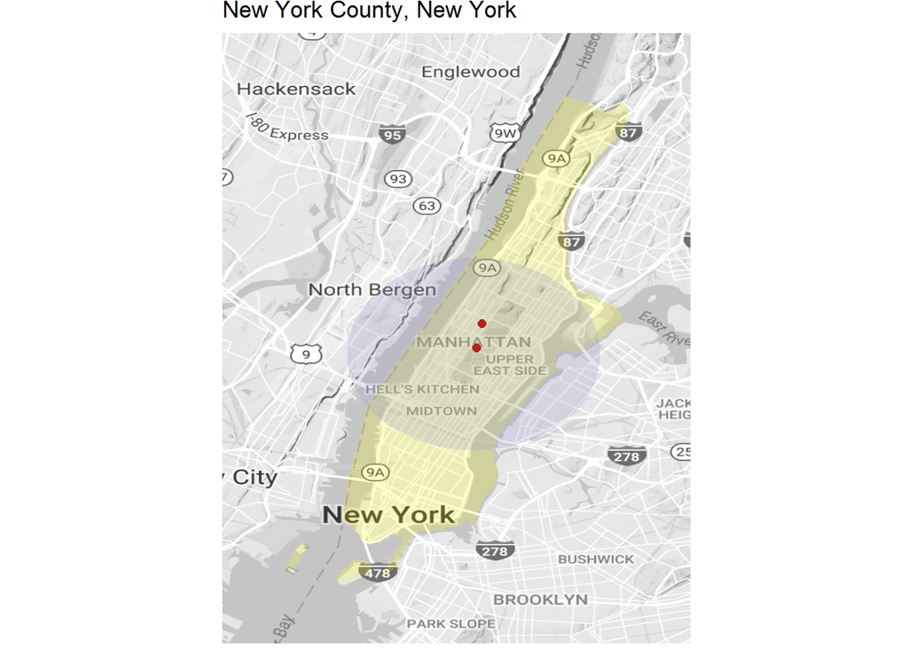

```
##
## $radius
## [1] 4.338249
##
## $lat_center
## [1] 40.77656
##
## $lon_center
## [1] -73.97017
```

```
NA
##         date  awnd  prcp awnd_reporting prcp_reporting
##       <date> <dbl> <dbl>          <int>          <int>
## 1 2012-10-28    52   0.0              1              1
## 2 2012-10-29    84  17.0              1              1
## 3 2012-10-30    34   6.9              1              1
## 4 2012-10-31    23   0.3              1              1
## 5 2012-11-01    26   0.0              1              1
## 6 2012-11-02    30   0.0              1              1
```

```
NA
##         date  awnd  prcp awnd_reporting prcp_reporting
##       <date> <dbl> <dbl>          <int>          <int>
## 1 2011-08-26     9   0.0              1              1
## 2 2011-08-27    34  73.2              1              1
## 3 2011-08-28    63 101.3              1              1
## 4 2011-08-29    18   0.0              1              1
## 5 2011-08-30    15   0.0              1              1
## 6 2011-08-31    10   0.0              1              1
```

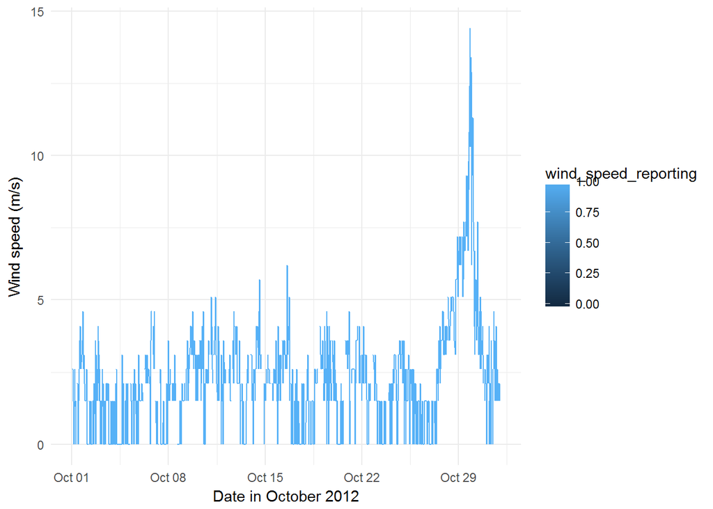

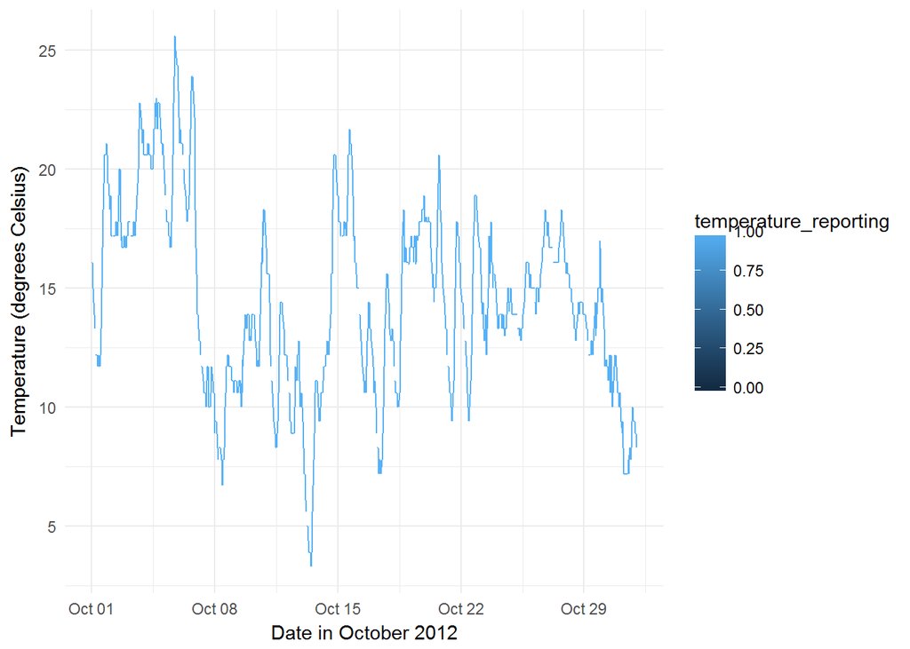

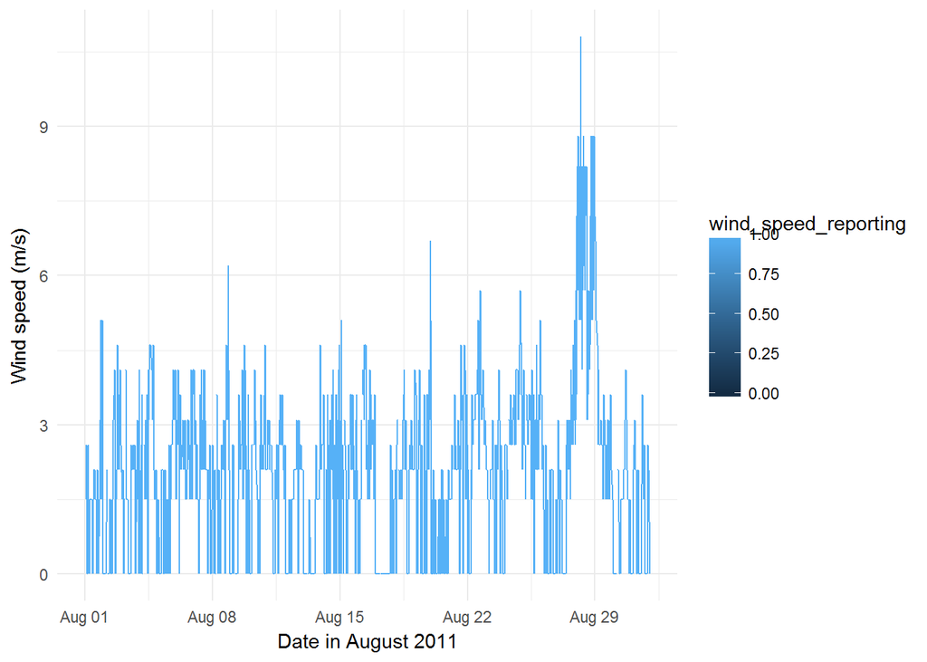

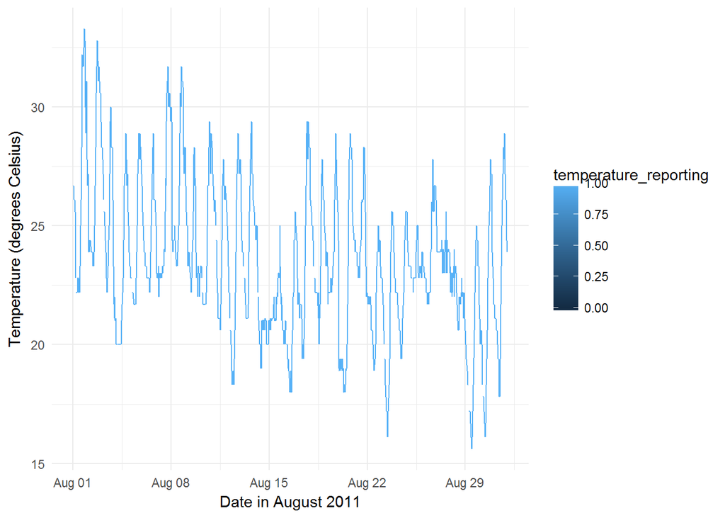

The daily weather data shows the weather in the week of Hurricane Sandy and Hurricane Irene clearly, on Oct. 29 2012 and Aug. 28, the average daily wind speed (tenths of meters per second) and the precipitation (mm) reached the maximum among the days. The wind brought by Hurricane Sandy and the rainfall brought by Hurricane Irene was very strong. The wind speed plots show the effect clearly, on Oct. 29 2012 and Aug. 28, the wind speed increased sharply. However, the effect on the temperature from the hurricanes were not apparent, even it was in the decreasing trend.

```
## Getting daily weather data for New York County, New York. This may take a while.
```

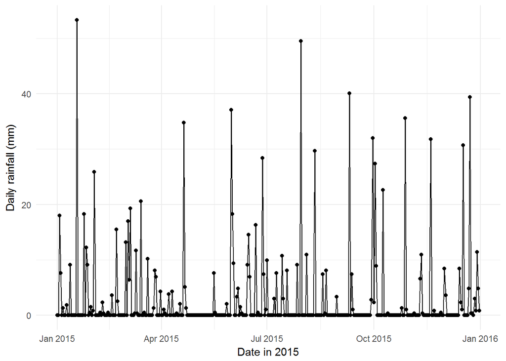

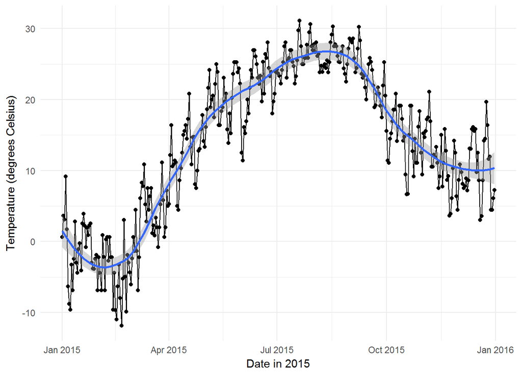

```
## 2015-01-01 2015-02-01 2015-03-01 2015-04-01 2015-05-01 2015-06-01
##  -1.141935  -4.410714   3.409677  12.370000  20.280645  21.768333
## 2015-07-01 2015-08-01 2015-09-01 2015-10-01 2015-11-01 2015-12-01
##  26.000000  26.093548  23.580000  14.472581  11.546667  10.437097
```

```
## [1] -4.410714
```

```
## [1] 26.09355
```

Here, we show series of analysis on the precipitation. The sum of the precipitation in each month is shown,and, basically, the variations between months are great and the rainfall and the snowfall was frequently. The amount of the daily precipitation mainly distributes over 0~10 mm. The minimum sum of monthly precipitation is 47.2 mm, and the maximum sum of monthly precipitation is 132.7 mm.

```
## 2015-01-01 2015-02-01 2015-03-01 2015-04-01 2015-05-01 2015-06-01
##      132.7       51.9      120.1       52.9       47.2      121.7
## 2015-07-01 2015-08-01 2015-09-01 2015-10-01 2015-11-01 2015-12-01
##      100.9       59.7       83.3       99.4       51.2      120.0
```

```
## [1] 47.2
```

```
## [1] 132.7
```

```
##               Index     prcp mean_temp
## Min.     2015-01-01   0.0000  -11.8500
## 1st Qu.  2015-04-02   0.0000    6.1000
## Median   2015-07-02   0.0000   15.2500
## Mean     2015-07-02   2.8520   13.8100
## 3rd Qu.  2015-10-01   0.5000   23.6000
## Max.     2015-12-31  53.3000   31.1000
## IQR            <NA>   0.5000   17.5000
## sd             <NA>   7.6880   10.5414
## cv             <NA>   2.6956    0.7633
## Skewness       <NA>   3.6887   -0.4218
## Kurtosis       <NA>  14.8782   -0.8606
## NA's           <NA>   0.0000    0.0000
## n              <NA> 365.0000  365.0000
```

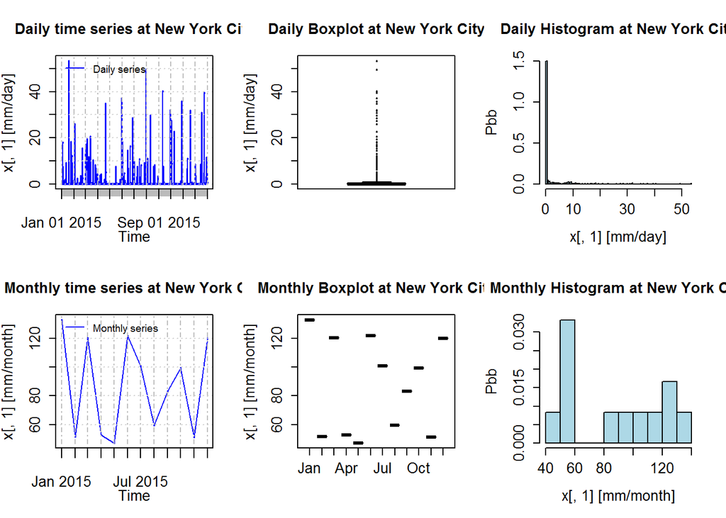

- 4.The difference between the weather of the urban area and the rural area in New York. Here, we choose Orange County as the rural area being analyzed. The weather stations map is shown as the geographical plot, and the head of the weather data of 2015 in Orange County is also presented.

```
## Getting daily weather data for Orange County, New York. This may take a while.
```

```
##                     Year    Amount
## 1   Averaged temperature 13.809726
## 2 Averaged precipitation  2.852055
```

```
##                     Year   Amount
## 1   Averaged temperature 9.809064
## 2 Averaged precipitation 3.041274
```

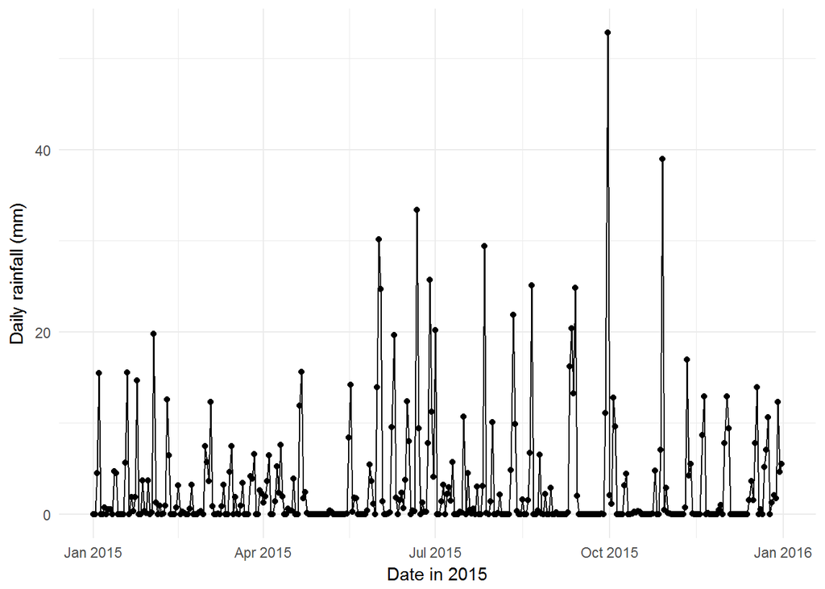

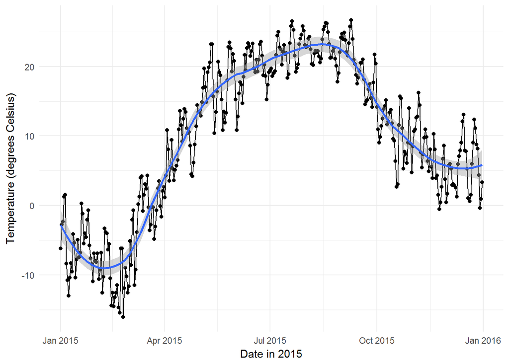

It is apparent that the average temperature in New York City is higher than that in Orange County, and the precipitation in New York City is lower than that in Orange County, which is also verified by the thermal island effect. From the plots, we find that the pattern of the temperature and the precipitation arount the whole year is similar.